# MBL

Alex Holcombe

2/27/2018

Analysis of MBL second day, both dual targets and one ring (at every end of file)

Script based mostly on https://github.com/alexholcombe/Cheryl_E2/blob/master/dataPreprocess/readInE2rawData.R

```r
rawDataPath<- file.path("..","data","MBL","secondDayDualRing")

files <- dir(path=rawDataPath,pattern='.txt')  #find all data files in this directory
dfAll<-data.frame()
print(files)
```

```
## [1] "MBL_14May2019_10-58.txt" "MBL_14May2019_11-04.txt"
## [3] "MBL_14May2019_11-06.txt" "MBL_14May2019_12-14.txt"
```

```r
for (i in 1:length(files)) { #read in each file
    fileThis<- file.path(rawDataPath,files[i])

    rawData<- tryCatch(
       read.table( fileThis,  sep="\t", header=TRUE, strip.white=TRUE),
       error=function(e) {
         stop( paste0("ERROR reading the file ",fname," :",e) )
       } )

    filename<-files[i]
    apparentSubjectName <- strsplit(filename,split="_")[[1]][1]
    print(paste("Apparent subject name about to load is",apparentSubjectName))
    subjectName<- as.character(  rawData$subject[1] )
    if (apparentSubjectName != subjectName) {
      stop( paste("WARNING apparentSubjectName",apparentSubjectName," from filename does not match subjectName in data structure",
                  subjectName, "in file",files[i]) )
    }
    rawData$file <- filename

    dfThis<-rawData # turnRawPsychopyOutputIntoMeltedDataframe(rawData)

    tryCatch(
      dfAll<-rbind(dfAll,dfThis), #if fail to bind new with old,
      error=function(e) { #Give feedback about how the error happened
        cat(paste0("Tried to merge but error:",e) )
      } )

}
```

```
## [1] "Apparent subject name about to load is MBL"
## [1] "Apparent subject name about to load is MBL"
## [1] "Apparent subject name about to load is MBL"
## [1] "Apparent subject name about to load is MBL"
```

Add SOA and letterDur to data, because I tested MBL at multiple values

```r
library(dplyr)
dfAll<- dfAll %>% mutate( SOA = case_when(file=="MBL_14May2019_10-58.txt" ~ 350,
                                          file=="MBL_14May2019_11-04.txt" ~ 400,
                                          file=="MBL_14May2019_11-06.txt" ~ 400,
                                          file=="MBL_14May2019_12-14.txt" ~ 350
                                          ))

dfAll<- dfAll %>% mutate( letterdurDesired = case_when(file=="MBL_14May2019_10-58.txt" ~ 200,
                                                file=="MBL_14May2019_11-04.txt" ~ 250,
                                                file=="MBL_14May2019_11-06.txt" ~ 300,
                                                file=="MBL_14May2019_12-14.txt" ~ 280) )

refreshRate <- 60
dfAll<- dfAll %>% mutate(   letterDurFrames = floor (letterdurDesired / (1000./refreshRate) )  )
#table(dfAll$letterdur, dfAll$letterDurFrames)
dfAll$letterdur <- dfAll$letterDurFrames * 1000/refreshRate

table(dfAll$SOA, dfAll$letterdur)
```

```
##
##       200 233.333333333333 266.666666666667 300
##   350   8                0               43   0
##   400   0                6                0  47
```

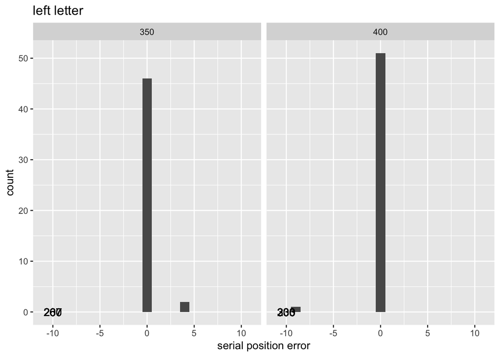

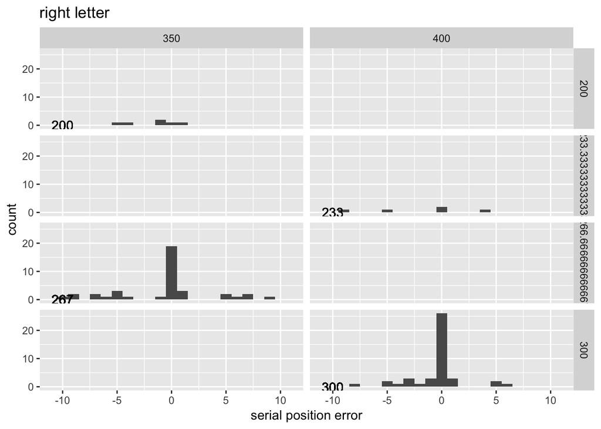

```r
library(ggplot2)
sanityVisualCheck<-TRUE
if (sanityVisualCheck) {

  g=ggplot(dfAll, aes(x=responsePosRelative0))
  #plot data
  g<-g+geom_histogram(binwidth=1) + xlab('serial position error') + facet_grid(.~SOA) + ggtitle('left letter')
  g <- g + geom_text(aes(x=-10,y=0,label=round(letterdur,0))) #paste("dur:",)))
  g<-g+ xlim(-11,11) #18 items per stream. Based on Kim's program so included letters that were never presented in the stream
  show(g)

  h=ggplot(dfAll, aes(x=responsePosRelative1))
  #plot data
  h<-h+geom_histogram(binwidth=1) + xlab('serial position error') +  facet_grid(letterdur~SOA) + ggtitle('right letter')
  h <-h + geom_text(aes(x=-10,y=0,label=round(letterdur,0))) #paste("dur:",)))
  h<-h+ xlim(-11,11) #18 items per stream. Based on Kim's program so included letters that were never presented in the stream
  show(h)


}
```

Melt. Error “attributes are not identical across measure variables; they will be dropped” seems OK.

```r
library(tidyr)

columnsToMelt<- colnames(dfAll)[11:20]
#https://stackoverflow.com/questions/23945350/reshaping-wide-to-long-with-multiple-values-columns
dl<-  dfAll %>%  gather(v, value, columnsToMelt)
#attributes dropped but that's ok
#Separate the new v column into 0 and 1 (corresponding to left and right)
dl<- dl %>% separate(col = v, into = c("col", "var"), sep = -1) #This means separate it at the last character,
  #which is always 0 or 1 corresponding to left and right
dl<- dl %>% arrange(file,trialnum) %>%
  spread(col, value) %>% rename(side=var, SPE=responsePosRelative)
rownames(dl)<-NULL

dl$SPE <- as.numeric(dl$SPE)
```

```r
numItemsInStream <- 17
dl<- dl %>% rename(targetSP = cueSerialPos)
#WHY DOES THE targetSP variable have to be called targetSP for plot_hist_with_fit when you have to pass the motherfucker? Because createGuessingDistribution creates guessing distribution from scratch. Is that necessary?
dl$targetSP <- as.numeric(dl$targetSP)
possibleTargetSP<- sort(unique(dl$targetSP))
minTargetSP <- min( possibleTargetSP )
maxTargetSP <- max( possibleTargetSP )
minSPE <- 1 - maxTargetSP
maxSPE <- numItemsInStream - minTargetSP
```

Plot after melting

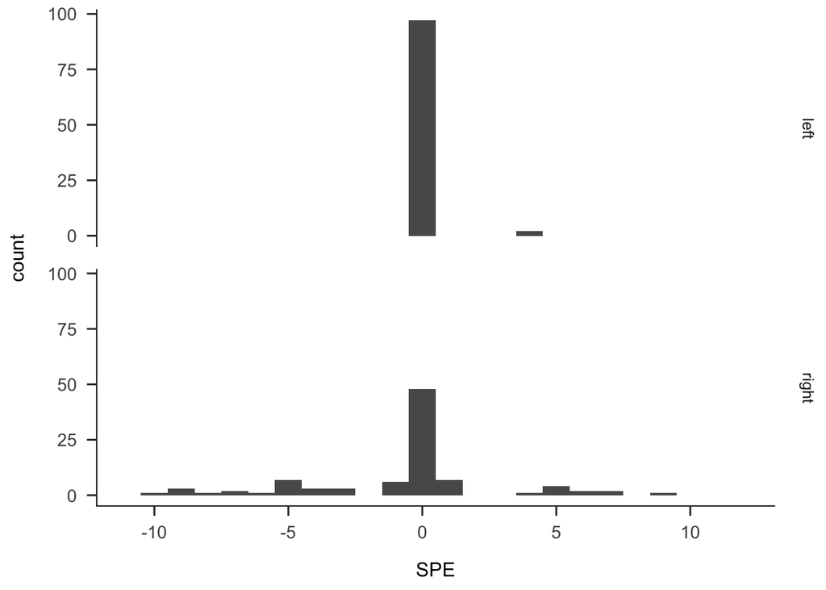

```r
dl<- dl %>% filter(experimentPhase=="main")
dl[dl$side=="0",]$side <- "left"
dl[dl$side=="1",]$side <- "right"

g=ggplot(dl, aes(x=SPE)) + theme_apa() + facet_grid(side~.)
#plot data
g<-g+geom_histogram(binwidth=1) + xlim(minSPE,maxSPE)
show(g)
```

```r
guessesFakeSPEs <- minSPE:maxSPE
guessesFakeSPEs <- guessesFakeSPEs[-pmatch(-3:3,guessesFakeSPEs)] #remove -3:3 to be sure they're modeled as part of the uniform distribution #https://stackoverflow.com/questions/49742315/how-to-delete-multiple-values-from-a-vector-but-not-all-of-them

dl[dl$SPE==-999,]$SPE <- sample(guessesFakeSPEs, size=sum(dl$SPE==-999),replace=TRUE)
```

Mixture model the left side

```r
dlLeft<- dl %>% filter(side=="left")

plotContinuousGaussian <- FALSE; annotateIt <- TRUE
j<- plot_hist_with_fit(dlLeft,minSPE,maxSPE,dlLeft$targetSP,numItemsInStream,plotContinuousGaussian,annotateIt, FALSE)
```

```
## Error in eigen(nhatend) : infinite or missing values in 'x'
## Error in eigen(nhatend) : infinite or missing values in 'x'
## Error in eigen(nhatend) : infinite or missing values in 'x'
```

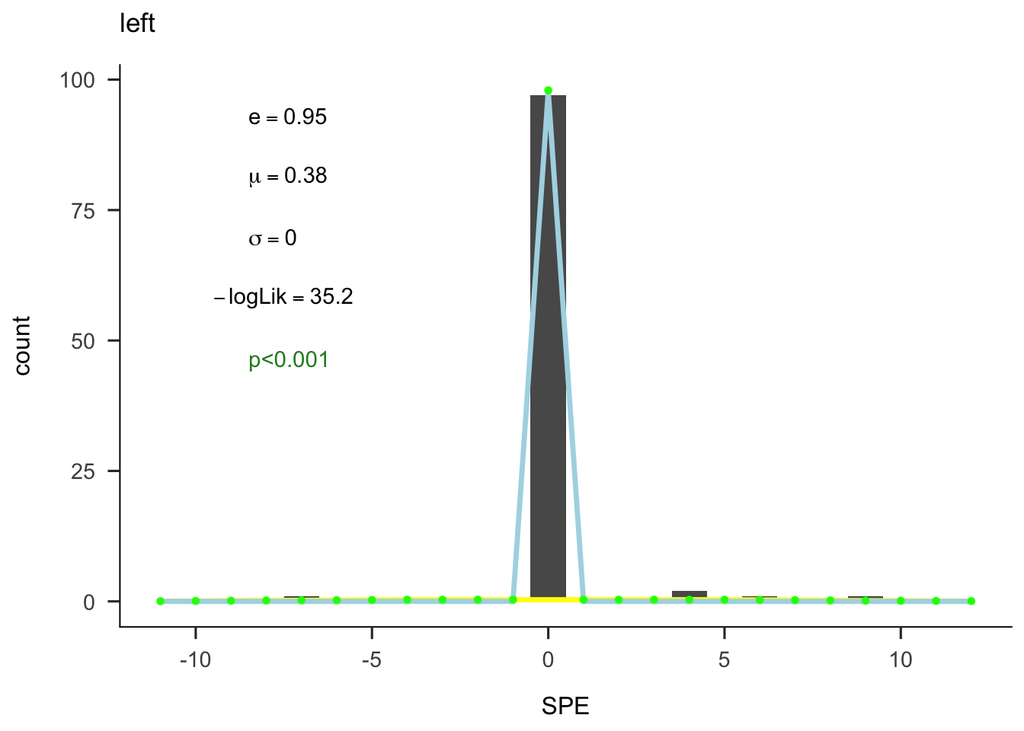

```r
j<- j + ggtitle("left")
show(j)
```

Mixture model the right side

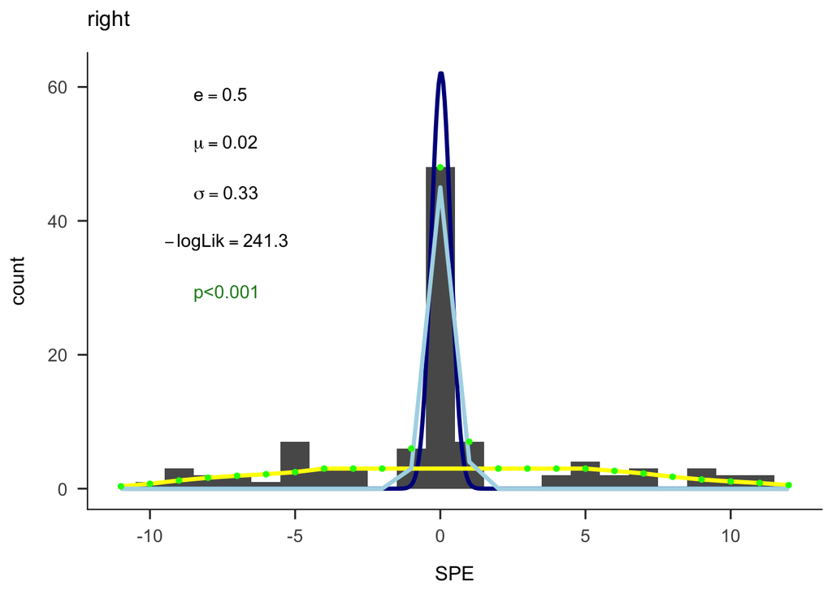

```r
dlRight<- dl %>% filter(side=="right")

plotContinuousGaussian <- TRUE; annotateIt <- TRUE
k<- plot_hist_with_fit(dlRight,minSPE,maxSPE,dlRight$targetSP,numItemsInStream,plotContinuousGaussian,annotateIt, FALSE)
k<- k + ggtitle("right")
show(k)
```

```r
library(readr) #has better than save.csv https://readr.tidyverse.org/reference/write_delim.html
pathToSave<- file.path("..","data","MBL")

saveRDS(dl, file = file.path(pathToSave,"dayTwo.rda"), compress="bzip2")
write_tsv(dl, file.path(pathToSave,"dayTwo.tsv"))
```

Load and analyze ONE RING data

```r
rawDataPath<- file.path("..","data","MBL","oneRing")

files <- dir(path=rawDataPath,pattern='.txt')  #find all data files in this directory
oneR<-data.frame()
print(files)
```

```
## [1] "MBL_14May2019_11-21.txt"
```

```r
fileThis<- file.path(rawDataPath,files[1])

rawData<- tryCatch(
  read.table( fileThis,  sep="\t", header=TRUE, strip.white=TRUE),
  error=function(e) {
    stop( paste0("ERROR reading the file ",fname," :",e) )
  } )
rawData$file <- fileThis

oneRing <- rawData %>% rename(SPE=responsePosRelative0)
oneRing$SOA <- 400
oneRing$letterdurDesired <- 250

refreshRate <- 60
oneRing<- oneRing %>% mutate(   letterDurFrames = floor (letterdurDesired / (1000./refreshRate) )  )
#table(dfAll$letterdur, dfAll$letterDurFrames)
oneRing$letterdur <- oneRing$letterDurFrames * 1000/refreshRate

table(oneRing$SOA, oneRing$letterdur)
```

```
##
##       233.333333333333
##   400               96
```

Performance is similarly bad for right side even when just one ring - no evidence of extinction, just as Mike also found when brief presentation.

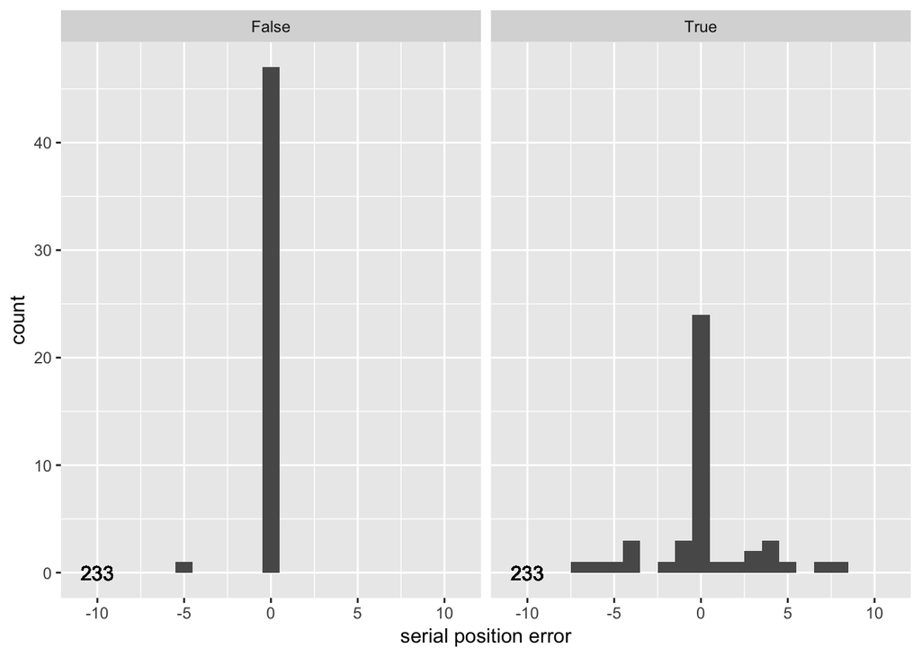

```r
library(ggplot2)

sanityVisualCheck<-TRUE
if (sanityVisualCheck) {

  g=ggplot(oneRing, aes(x=SPE))
  #plot data
  g<-g+geom_histogram(binwidth=1) + xlab('serial position error') + facet_grid(.~leftRight)
  g <- g + geom_text(aes(x=-10,y=0,label=round(letterdur,0))) #paste("dur:",)))
  g<-g+ xlim(-11,11) #18 items per stream. Based on Kim's program so included letters that were never presented in the stream
  show(g)

}
```

```r
guessesFakeSPEs <- minSPE:maxSPE
guessesFakeSPEs <- guessesFakeSPEs[-pmatch(-3:3,guessesFakeSPEs)] #remove -3:3 to be sure they're modeled as part of the uniform distribution #https://stackoverflow.com/questions/49742315/how-to-delete-multiple-values-from-a-vector-but-not-all-of-them

oneRing[oneRing$SPE==-999,]$SPE <- sample(guessesFakeSPEs, size=sum(oneRing$SPE==-999),replace=TRUE)
```

```r
numItemsInStream <- 17
oneRing<- oneRing %>% rename(targetSP = cueSerialPos0)

possibleTargetSP<- sort(unique(oneRing$targetSP))
minTargetSP <- min( possibleTargetSP )
maxTargetSP <- max( possibleTargetSP )
minSPE <- 1 - maxTargetSP
maxSPE <- numItemsInStream - minTargetSP
```

Mixture model the right side

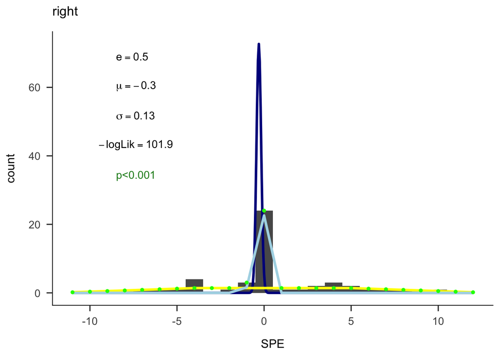

```r
oneRing<- oneRing %>% mutate( leftRight = case_when(leftRight=="True" ~ TRUE,
                                          leftRight=="False" ~ FALSE
                                          ))

oneRingRight<- oneRing %>% filter(leftRight==TRUE)   #ignore guesses of letters that weren't in the stream. Could alternatively give them random values

plotContinuousGaussian <- TRUE; annotateIt <- TRUE
k<- plot_hist_with_fit(oneRingRight,minSPE,maxSPE,oneRingRight$targetSP,numItemsInStream,plotContinuousGaussian,annotateIt, FALSE)
k<- k + ggtitle("right")
show(k)
```

```r
library(readr) #has better than save.csv https://readr.tidyverse.org/reference/write_delim.html
pathToSave<- file.path("..","data","MBL")

saveRDS(oneRing, file = file.path(pathToSave,"oneRing.rda"), compress="bzip2")
write_tsv(oneRing, file.path(pathToSave,"oneRing.tsv"))
```